# Программа для MANOVA Repeated для неполных данных с примером

Анна Рукавишникова

14 июня 2020 г

# Загрузка необходимых библиотек

```r
knitr::opts_chunk$set(echo = TRUE)
library(readr)
library(Rfast)
library(funModeling)
library(Hmisc)
library(corrplot)
library(PerformanceAnalytics)
library(ggplot2)
library(plyr)
library(GGally)
library(lsmeans)
library(car)
library(MASS)
library(pracma)
library("magic")
library("corpcor")
library(readxl)
library(Matrix)
library(SMFilter)
library(holodeck)
library(dplyr)

source("funcsAR_7.R")
Group <- TRUE
eps <- 1/10^5
```

# Описание требований к входным данным

Входные данные для анализа должны содержать следующие переменные: * группировочная переменная $group$ (со значениями 1,2) типа numeric, * переменные, измеряемые в несколько моментов времени в виде $COLr_k$ – $r$-ая переменная в $k$-ый момент времени, где $r = 1, \ldots, p$, $k = 1, \ldots, t$ типа numeric. Здесь подразумевается не ограничение на названия переменных, а их чёткий порядок внутри датафрейма, который необходим для правильной работы программы.

!Важно, чтобы группировочная переменная была определена для всех имеющихся наблюдений.

```r
data_example <- sim_cat(n_obs = 10, n_groups = 2, name = "group") %>%
  sim_covar(n_vars = 9, var = 1, cov = 0.0, name = "COL") %>%
  group_by(group) %>%
  ungroup()
data_example$group <- ifelse(data_example$group == "a",1,2)
colnames(data_example) <- c("group", "COL1_1","COL1_2","COL1_3","COL2_1","COL2_2","COL2_3","COL3_1","COL3_2","COL3_3")
data_example
```

```
## # A tibble: 10 x 10
##    group COL1_1 COL1_2  COL1_3  COL2_1  COL2_2  COL2_3  COL3_1 COL3_2
##    <dbl>  <dbl>  <dbl>   <dbl>   <dbl>   <dbl>   <dbl>   <dbl>  <dbl>
##  1     1 -0.357  0.475 -0.162  -0.489  -0.992  -0.0170  1.81    1.44
##  2     1  0.115 -0.225  1.66   -0.652   1.03   -0.0921  0.938  -0.414
##  3     1 -0.319 -0.487 -2.25    0.885   0.215   0.436   0.0321  0.685
##  4     1 -0.373 -0.309 -1.14    0.0696 -1.37    1.58   -0.304   0.486
##  5     1  1.01  -1.42   1.40    0.669   0.927   0.186   1.49   -0.461
##  6     2 -0.419  1.15  -1.05   -0.556  -0.718  -1.46    0.624   0.704
##  7     2 -1.02  -0.465  2.05   -0.0635  0.0697  0.956   0.0219 -1.09
##  8     2  0.313  0.968  0.191  -0.388  -2.24   -0.0200  0.408   0.394
##  9     2  1.35  -0.371 -0.166   1.12   -1.51   -0.575   0.818   0.430
## 10     2 -0.441 -1.09  -0.0474 -2.25    0.212  -0.0185 -1.84   -0.930
## # ... with 1 more variable: COL3_3 <dbl>
```

Описание параметров функции MANOVARM_with_missing_data(input_data, g, p, t, effect, epsilon, plt, plot_type, grnames):

- input_data – входные данные в описанном выше виде,
- g – количество групп,
- p – количество различных признаков в фиксированной временной точке,
- t – количество временных точек,
- effect (“group”, “time”, “interaction”) – интересующий эффект: группы, времени или взаимодействия (по умолчанию effect = “group”),
- epsilon – параметр критерия остановки итерационного подхода, используемого для оценивания корреляционной матрицы ошибок (по умолчанию epsilon = 0.00001),
- plt (TRUE, FALSE) – индикатор, определяющий, нужно ли будет строить график взаимодействия (TRUE (по умолчанию) – график строится, FALSE - график не строится)
- plot_type (“plot”, “ggplot”) – параметр, определяющий вид графика взаимодействия (“ggplot”(по умолчанию) - цветной график, рисуется с помощью функции ggplot, “plot” - стандартный график, рисуется с помощью функции plot)
- grnames – вектор, содержащий названия групп для отображения на графике (порядок названий в векторе важен, т.е. первый элемент вектора соответствует группе 1, второй – группе 2 и т.д.),

# Реализация методов

```r
#Функция для проверки того, что все элементы в листе одинаковые
allSame <- function(x) length(unique(x)) == 1

#Функция для предварительной обработки данных, которая обеспечивает: 1)полноту данных по всем признакам в первой временной точке(где должно быть меньше всего пропусков), 2)согласованность пропусков в каждой строке данных
data_preparation <- function(input_data,p,t) {

  df <- input_data

  #обеспечиваем полноту данных по всем признакам в первой временной точке
  df1 <- df[complete.cases(df[,c(1,seq(2,ncol(df),t))]),]

  #обеспечиваем согласованность пропусков в данных
  df2 <- df1

  for (i in (1:nrow(df1))) {
    for (j in (1:(t-1))) {
      if (! (((sum(is.na(df1[i,seq((2+j),ncol(df1),t)])) == 0) | (sum(is.na(df1[i,seq((2+j),ncol(df1),t)])) == p)))) {
        df2[i,c(seq((2+j),ncol(df1),t))] <- rep(NA,p)
      }
    }
  }

  return(df2)
}

#Функция для нахождения коэффициентов линейной комбинации, обеспечивающих максимальное различие между индивидами по фактору группы
group_effect <- function(input_data, g, p, t, epsilon) {

  df3 <- data_preparation(input_data,p,t)

  #рассматриваем одномерные повторные наблюдения с пропусками в рамках каждого признака
  Z.all <- list()
  H.all <- list()
  H_.all <- list()
  S_.all <- list()
  theta_hat.all <- list()
  mu_hat.all <- list()

  j <- 1

  #цикл по всем различным признакам
  for (i in seq(2,ncol(df3),t)) {

    df4 <- df3[,c(1,i:(i+(t-1)))]
    ANOVA_RM <- AU.2(df4, eps, Group)
    Z.all[[j]] <- ANOVA_RM$group.params$Z
    H.all[[j]] <- as.matrix(ANOVA_RM$group.params$H)
    S_.all[[j]] <- as.matrix(ANOVA_RM$group.params$R_)
    H_.all[[j]] <- as.matrix(ANOVA_RM$group.params$H_)
    theta_hat.all[[j]] <- ANOVA_RM$group.params$teta
    mu_hat.all[[j]] <- ANOVA_RM$group.params$mu
    j <- j + 1
  }

  #матрица наблюдений
  Z <- do.call(cbind, Z.all)

  #матрицы плана полной и усечённой моделей
  if ((length(unique(H.all)) == 1) & (length(unique(H_.all)) == 1)) {
    H <- H.all[[1]]
    H_ <- H_.all[[1]]
  } else {print("Ошибка: разные матрицы плана")}

  #оценка матрицы параметров для полной модели
  theta_hat <- do.call(cbind, theta_hat.all)

  #оценка матрицы параметров для усечённой модели
  mu_hat <- do.call(cbind, mu_hat.all)

  #итерационная продедура оценивания корреляционной матрицы ошибок линейной комбинации S
  S_L <- eye(nrow(H))
  repeat
  {
    S_L_1 <- S_L

    #матрицы остаточных сумм квадратов и произведений
    R0 <- data.frame(matrix(NA, nrow = p, ncol = p))
    R1 <- data.frame(matrix(NA, nrow = p, ncol = p))

    for (i in 1:p)
    {
      for (j in 1:p)
      {
          R0[i,j] <- t(Z.all[[i]] - H%*%theta_hat.all[[i]]) %*% S_L%*% (Z.all[[j]] - H%*%theta_hat.all[[j]])
          R1[i,j] <- t(Z.all[[i]] - H_%*%mu_hat.all[[i]]) %*%S_L%*% (Z.all[[j]] - H_%*%mu_hat.all[[j]])
      }
    }

    R0 <- as.matrix(R0)
    R1 <- as.matrix(R1)

    #Находим собственный вектор, т.е. коэффициенты линейной комбинации
    A <- sapply((eigen(solve(R0)%*%(R1-R0)))$vectors[,which.max(eigen(solve(R0)%*%(R1-R0))$values)], Re)

    #Считаем p-значение из ANOVA Repeated, используя полученные коэффициенты линейной комбинации
    df5 <- data.frame(matrix(NA, nrow = nrow(df3), ncol = 1))
    colnames(df5) <- "group"
    df5$group <- df3$group
    for (i in c(2:(t+1)))
    {
      df5[,i] <- as.matrix(df3[,c(seq(i,ncol(df3),t))])%*%A
    }

    ANOVA_RM <- AU.2(df5,eps,Group)
    p.val<- ANOVA_RM$P.values[2]

    S_L <- ANOVA_RM$group.params$R_

    if (FDist2(S_L,S_L_1) <= epsilon) {break}
  }

  #вычисляем матрицы остаточных сумм квадратов и произведений
  R0 <- data.frame(matrix(NA, nrow = p, ncol = p))
  R1 <- data.frame(matrix(NA, nrow = p, ncol = p))

  for (i in 1:p)
    {
    for (j in 1:p)
      {
      R0[i,j] <- t(Z.all[[i]] - H%*%theta_hat.all[[i]]) %*% S_L%*% (Z.all[[j]] - H%*%theta_hat.all[[j]])
      R1[i,j] <- t(Z.all[[i]] - H_%*%mu_hat.all[[i]]) %*%S_L%*% (Z.all[[j]] - H_%*%mu_hat.all[[j]])
      }
    }

  R0 <- as.matrix(R0)
  R1 <- as.matrix(R1)

  #находим собственный вектор, т.е. искомые коэффициенты линейной комбинации
  A <- sapply((eigen(solve(R0)%*%(R1-R0)))$vectors[,which.max(eigen(solve(R0)%*%(R1-R0))$values)], Re)
  if (all(A < 0)) {A <- -A}

  df5 <- data.frame(matrix(NA, nrow = nrow(df3), ncol = 1))
  colnames(df5) <- "group"
  df5$group <- df3$group
  for (i in c(2:(t+1)))
    {
    df5[,i] <- as.matrix(df3[,c(seq(i,ncol(df3),t))])%*%A
    }

  colnames(df5) <- c("group",paste("Time", 1:t, sep = ""))

  ANOVA_RM <- AU.2(df5, eps,Group)

  p_value<- ANOVA_RM$P.values[2]

  return(list(arm_data=df5, A=A, p_value = p_value))
}

#Функция для нахождения коэффициентов линейной комбинации, обеспечивающих максимальное различие между индивидами по факторам времени или взаимодействия
time_and_interaction_effect <- function(input_data, g, p, t, effect) {

  df3 <- data_preparation(input_data,p,t)

  #рассматриваем одномерные повторные наблюдения с пропусками в рамках каждого признака
  Y.all <- list()
  H.all <- list()
  Lambda.all <- list()

  j <- 1

  for (i in seq(2,ncol(df3),t)) {
    df4 <- df3[,c(1,i:(i+(t-1)))]
    ANOVA_RM <- AU.2(df4, eps, Group)
    Y.all[[j]] <- ANOVA_RM$ep$Y
    H.all[[j]] <- as.matrix(ANOVA_RM$ep$plan)
    Lambda.all[[j]] <- as.matrix(ANOVA_RM$ep$Lambda)
    j <- j + 1
}

  #матрица наблюдений
  Y <- as.matrix(do.call(cbind, Y.all))

  #матрица плана полной и усечённой моделей
  if (allSame(H.all) == TRUE) {
    H <- H.all[[1]]
    if (effect == "time") {H_u <- as.matrix(H[,-c(seq(1,ncol(H),g))])}
    else if (effect == "interaction") {H_u <- as.matrix(H[,c(seq(1,ncol(H),g))])}
    } else print("Ошибка: разные матрицы план")

  if (allSame(lapply(Lambda.all,function(x) rownames(x) <- c())) == TRUE) {Lambda <- Lambda.all[[1]]} else   print("Ошибка: разные корреляционные матрицы")

  #оценка матрицы параметров для полной модели
  theta_hat<- ginv(t(H)%*%ginv(Lambda)%*%H)%*%(t(H)%*%ginv(Lambda)%*%Y)

  #оценка матрицы параметров усечённой модели
  theta_hat_u <- ginv(t(H_u)%*%ginv(Lambda)%*%H_u)%*%(t(H_u)%*%ginv(Lambda)%*%Y)

  #матрицы остаточных сумм квадратов и произведений
  R0 <- t(Y - H%*%theta_hat)%*%ginv(Lambda)%*%(Y - H%*%theta_hat)
  R1 <- t(Y - H_u%*%theta_hat_u)%*%ginv(Lambda)%*%(Y - H_u%*%theta_hat_u)


  #Получаем коэффициенты линейной комбинации
  A <- sapply((eigen(solve(R0)%*%(R1-R0)))$vectors[,which.max(eigen(solve(R0)%*%(R1-R0))$values)], Re)
  if (all(A < 0)) {A <- -A}

  #Считаем p-значение из ANOVA Repetaed, используя полученные коэффициенты линейной комбинации.
  df5 <- data.frame(matrix(NA, nrow = nrow(df3), ncol = 1))
  colnames(df5) <- "group"
  df5$group <- df3$group

  for (i in c(2:(t+1)))
      {
        df5[,i] <- as.matrix(df3[,c(seq(i,ncol(df3),t))])%*%A
  }

  colnames(df5) <- c("group",paste("Time", 1:t, sep = ""))

  ANOVA_RM <- AU.2(df5,eps,Group)

  if (effect == "time") {p_value <- ANOVA_RM$P.values[3]}
  else if (effect == "interaction") {p_value <- ANOVA_RM$P.values[4]}

  return(list(arm_data = df5, A=A, p_value = p_value))
}

#Построение графика взаимодействия
interaction_plot <- function(arm_data, grnames, g, t, type) {

  df5 <- arm_data

  val <- do.call("rbind", lapply(c(1:g), function(y) do.call("rbind", lapply(2:(t+1), function(x) na.omit(df5[df5$group == y,x])))))

  ng <- lapply(c(1:g), function(y) sapply(2:(t+1), function(x) length(na.omit(df5[df5$group == y,x]))))

  gr <- data.frame(grnames,  stringsAsFactors=FALSE)
  gr$counts <- sapply(ng, function(x) sum(x))

  group <- data.frame(do.call(c,sapply(c(1:nrow(gr)), function(x) rep(gr[x,1],gr[x,2]))))

  rept <- rbind(rep(c(1:t),g),do.call(c, ng))
  time <- data.frame(do.call(c, sapply(c(1:ncol(rept)), function(x) rep(rept[1,x],rept[2,x]))))

  interaction_df <- cbind(val,group,time)

  colnames(interaction_df) <- c('value','group','time')

  if (type == "plot")
  {
   plot(interaction.plot(interaction_df$time, interaction_df$group, interaction_df$value, xlab = 'Момент времени', ylab = 'Среднее значение <<нового признака>>', trace.label = 'Группа',main = "График взаимодействия"))
  }

  else if (type == "ggplot")
  {
    interaction_df$time.cat <- factor(interaction_df$time, labels=paste("t", c(1:t), sep=""))
    df <- with(interaction_df , aggregate(value, list(group=group, time=time.cat), mean))
    df$n <- do.call(c, ng)

    lp <- ggplot(data = df, aes(x = time, y = x, group = group, shape = group, colour = group, linetype = group)) + geom_line() + geom_point(size = 3)

    plot(lp + scale_colour_discrete(name  ="Группа", breaks=grnames, labels=grnames) +
         scale_shape_discrete(name  ="Группа", breaks=grnames, labels=grnames) +
         scale_linetype_discrete(name  ="Группа", breaks=grnames, labels=grnames) +
         theme_bw() + ylab("Среднее значене <<нового признака>> ") + xlab("Время") +
         ggtitle("График взаимодействия"))
  }


}

MANOVARM_with_missing_data <- function(input_data, g, p, t, effect = "group", epsilon = 0.00001, plt = TRUE, plot_type = "ggplot", grnames = c("group1","group2")) {

  if (effect == "group") {
    results <- group_effect(input_data, g, p, t, epsilon)
  } else
  if ((effect == "time") | (effect == "interaction")) {
    results <- time_and_interaction_effect(input_data, g, p, t, effect)
  }

  if (plt == TRUE) {
    arm_data <- results$arm_data
    interaction_plot(arm_data, grnames, g, t, plot_type)
  }


  #в качестве результата работы программы, будем выдавать p-value, вектор коэффициентов линейной комбинации и график взаимодействия (при необходимости)
  A <- results$A
  p_value <- results$p_value

  return(list(A=A, p_value = p_value))
}
```

# Демонстрация работы программы для реальных данных

```r
Cryodestruction_data <- read_csv("C:/Master_degree/Cryodestruction_data.csv")
data <- Cryodestruction_data[,-1]
head(data)
```

[output not shown]

## Эффект группы

```r
res <- MANOVARM_with_missing_data(input_data = data, g = 2, p = 2, t = 2, effect = "group", plt = FALSE)
res$A
```

```
## [1] 0.9003559 0.4351543
```

```r
res$p_value
```

```
## p_value_alpha
##    0.02180904
```

## Эффект времени

```r
res <- MANOVARM_with_missing_data(input_data = data, g = 2, p = 2, t = 2, effect = "time", plt = FALSE)
res$A
```

```
## [1] 0.4398950 0.8980492
```

```r
res$p_value
```

```
##    p_value_b
## 2.220446e-16
```

## Эффект взаимодействия

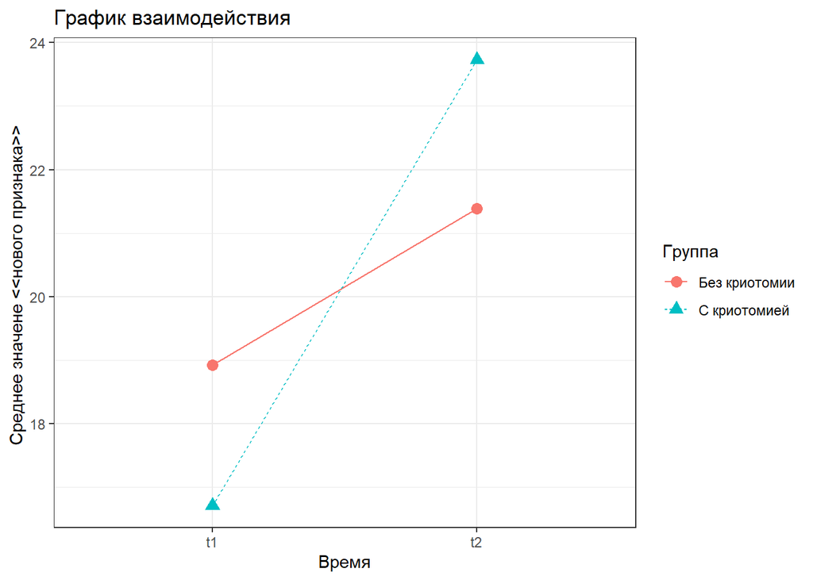

```r
res <- MANOVARM_with_missing_data(input_data = data, g = 2, p = 2, t = 2, effect = "interaction", plt = TRUE, plot_type = "ggplot", grnames = (c("Без криотомии", "С криотомией")))
```

```r
res$A
```

```
## [1] 0.07470249 0.99720587
```

```r
res$p_value
```

```
##   p_value_g
## 4.72046e-05
```